# Markov Processes - Foundations of Stochastic Models of Finance

Ivan E. Perez

January 17, 2019

Welcome to the Foundations of Stochastic Models of Finance series. This is a small set of blogposts that will let me build up to the traditional short derivation of BSM-OPM. These posts are meant to communicate an intuitive feel of the underlying principles and assumptions we need to get to BM-OPM.

##### The Markov Chain:

The Markov chain is a sequence of Random Variables with the Markov Property.

##### The Markov Property:

The Markov Property states that future and past states are independent.

$$P\left \{
X_{n+1} = j | X_{n}=i, X_{n-1}=i_{n-1}, ..., X_{0}=i_{0}
\right \} = p_{ij}$$

In English: The conditional probability of the next state given all past states including the present state is a preset probability.

$$p_{ij} = \left \{
X_{n+1}=j| X_n= i_n
\right \}$$
$$\forall n, i_0,...,i_{n-1},i_n, j$$
Where
$$i, j \in \left \{ 1,2, ... , M\right \}$$
represents discrete state space.

##### Transition Graphs and Matrices

Now, that we know Markov Processes probabilites are not “informed” by any past or future state, we can describe transitions from State A to State B using a transition and set probabilies.

Let $P$ be the $M \times M$ Transition Matrix containing the transition probabilities from state $i\rightarrow j$. (i.e. each element in the matrix, is giving me a probability that you can move from state $i$ to state $j$).

$$P =
\left [ \begin{array}{cccc}
p_{11} & p_{12} & \cdots & p_{1M} \\
p_{21} & p_{22} & \cdots & p_{2M} \\
\vdots & \vdots & \ddots & \vdots \\
p_{M1} & p_{M2} & \cdots & p_{MM}
\end{array} \right]$$
Lets give the transition matrix some values.
$$P =
\left [ \begin{array}{cccc}
0 & 0.5 & 0 & 0 \\
0.5 & 0 & 0.25 & 0.25 \\
0 & 0.4 & 0.4 & 0.2 \\
0 & 0 & 0 & 1
\end{array} \right]$$

Transition graphs are just small plots that we can use to intuitively display the transition matrix. In this case, moving from state $1$ to state $2$ has a 50% chance of occuring.

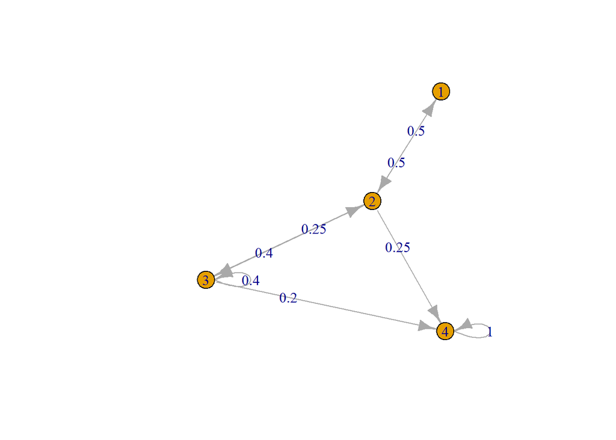

#### Classification of States

##### Accessible States:

There is a directed path in the transition grapsh/matrix such that the transition probability from state $i$ to $j$ is non-zero.

##### Communicable States:

There is a non-zero probability from state $i$ to $j$ and there is a non-zero probabiltiy moving from $j$ to $i$.

##### Recurrent States:

For every state $j$ that is accessible from $i$ the state $i$ is also accessible from $j$.

##### Absorbing States:

The probability of transitioning from $i$ to $j$ and $j$ to $i$ is $1$.

#### Example: Gamblers Ruin

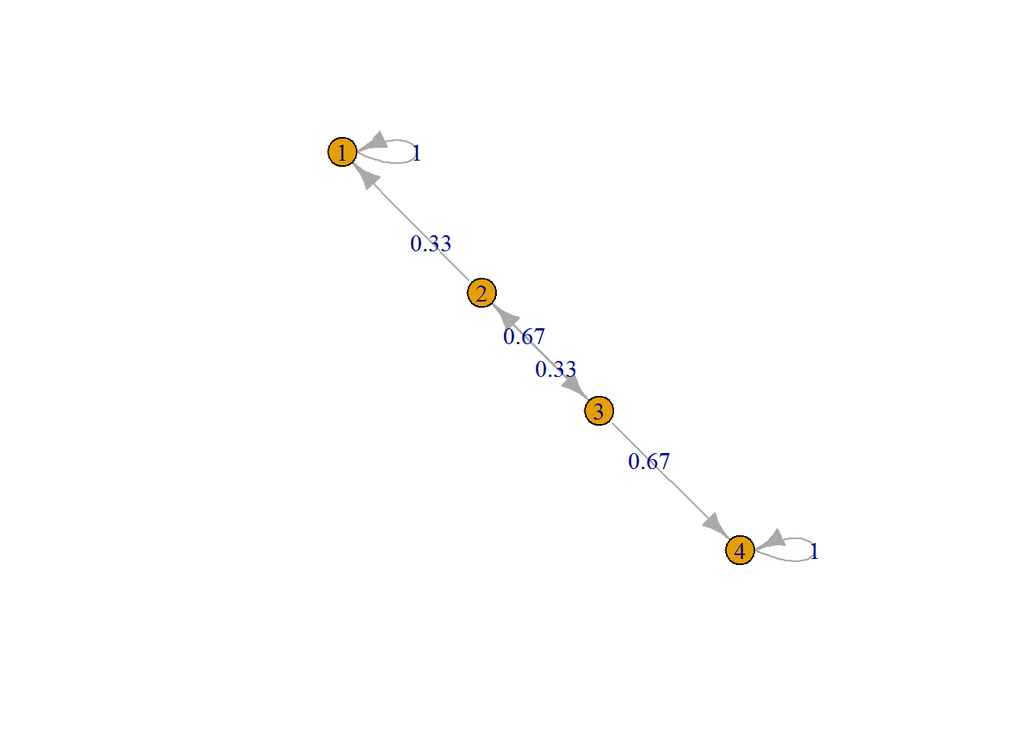

Now lets show the transition matrix $GR$.

$$GR =
\left [ \begin{array}{cccc}
1 & 0 & 0 & 0 \\
1/3 & 0 & 2/3 & 0 \\
0 & 1/3 & 0 & 2/3 \\
0 & 0 & 0 & 1
\end{array} \right]$$

What can we take away from this? We can extended this to build someething like a blackjack odds calculator. But, the most important thing is to remember that when we hear the word Markov Property. **The Markov Property simply tells us, the probability of the next movement is independent of any of the past(and future) states.**

*Sounds eerily like the disclaimer of every investment product.*